# A3: SPL Library Checkouts

### Introduction

The Seattle Public Library’s Checkouts by Title data allows for viewers to gain a deeper understanding of checkout trends within Seattle’s library system. Providing information about every book or media that has been checked out since 2005, the data can tell users about the popularity and various aspects of books, eBooks, audiobooks, and other forms of physical and electronic media. I chose to focus on one of my favorite childhood series, A Series of Unfortunate Events, written by Lemony Snicket. This series is offered in both eBook and Audiobook form at the Seattle Public Library. Because these books were such a large part of my childhood, I was interested to explore its popularity in this generation of readers. The series has had many renditions during and after its publication which ended in 2006. The series has been retold in both a movie which came out in 2004, as well as a popular series airing on Netflix from 2017-2019. Since the story have managed to stay relevant, let’s see if the books have done the same.

### The Dataset

The Checkouts by Title dataset was aggregated and published by the Seattle Public Library. This extensive dataset was started in April 2005 and is updated monthly. Because this dataset is so large, I used the data of all checkouts from 2022-2023 to create a smaller dataset for my own project. For this dataset, I chose to focus on Lemony Snicket’s, A Series of Unfortunate Events Book series. The dataset consists of each checked out book’s usage class, checkout type, material type, checkout year, checkout month, checkouts, title, ISBN, creator, subjects, publisher, and publication year. The data was collected from multiple sources, but because this particular series is only offered in eBook and audiobook format, its usage data is provided by OverDrive, hoopla, Freegal, and RBDigital. The Checkouts by Title data was first collected by George Legrady’s art installation in the Central Library. This art piece had been recording checkout data since 2005 and was later used by the Seattle Public Library to create this dataset and share it with Seattle’s open data portal. The dataset was published as part of the Open Data Initiative, urging cities to be transparent with their public data as a means to promote public interaction and problem solving. Because the data is anonymous in both exact checkout date and recipient, there aren’t any ethical implications of publicly sharing this data. My only issue with the dataset was the lack of information regarding how many copies are available of each book. Not knowing their availability makes it hard to compare checkout numbers of different books, since one may be lower simply because there are less copies. This is also misleading when trying to determine the popularity of a book, one with a low number of checkouts may be due to the fact it is constantly checked out and there are only a few versions. I had to base my conclusions off the data given, however, I recognize that this issue may affect the accuracy of my claims.

### First Trends Over Time Chart

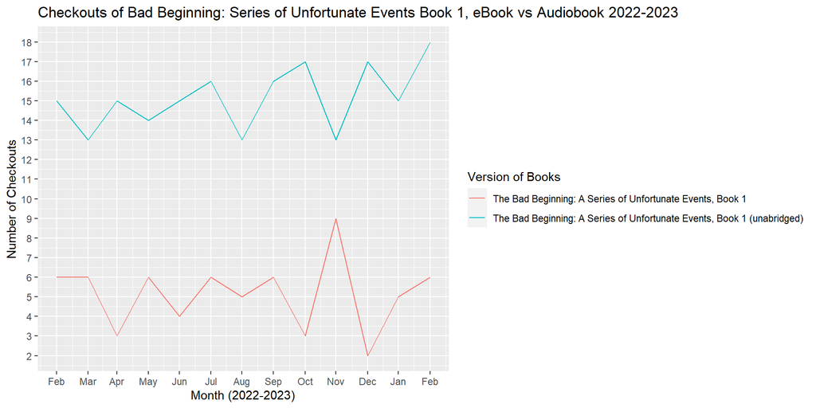

### Second Trends Over Time Chart

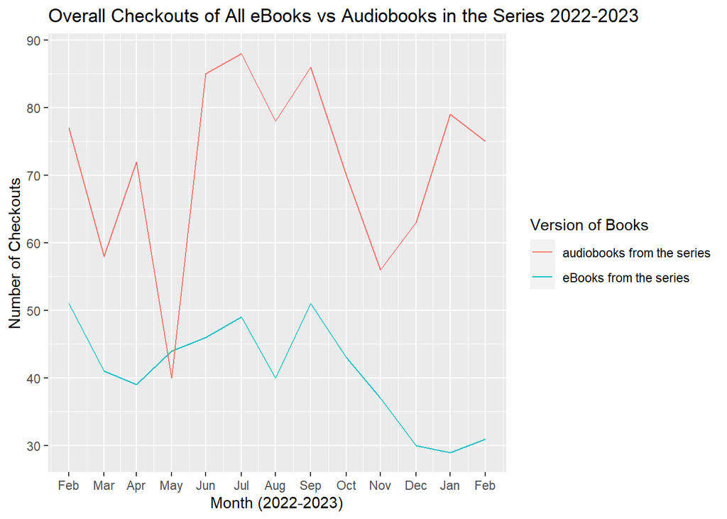

This chart shows the overall checkout count of all eBooks vs audiobooks in the series per month in 2022-2023. This chart allows us to understand the overall interaction with each version of the series throughout the year and determine their overall checkout frequency. From the chart we are able to see that there is more overall interaction with the audiobooks than the eBooks, though both versions get continuous interaction. While audiobook checkouts have continued to remain high, eBook checkouts have been on a constant decline since September 2022. We can see that this was shortly followed by an increase in audiobook checkouts, indicating an increased interest in the audio version over the eBook version. Though eBooks were briefly more popular in May 2022, it is clear that the audiobook version is the preferred way to interact with the series. This confirms the trend we observed in the first chart, people are continuously choosing the audio version of these books over the eBook version.

### Bar Charts

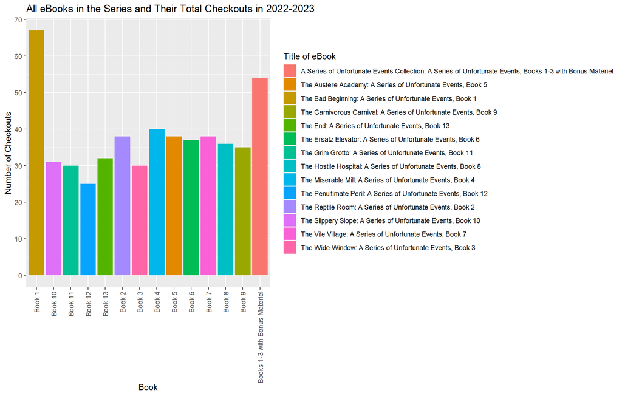

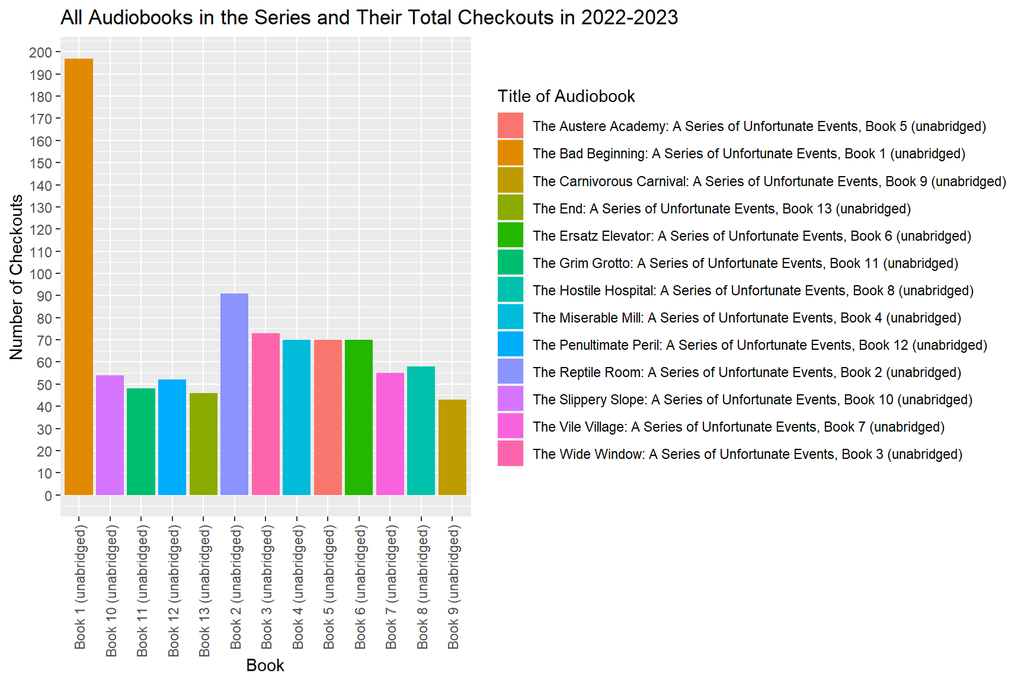

For my final chart, I had to split the data into two separate bar graphs to be able to compare how much each version of the series was being read through. These graphs show the total checkouts for each audiobook and eBook in the series from 2022-2023. From this chart we are able to see the consistency of checkouts across all books, indicating how many people are reading through the whole series. From these last charts we are able to conclude that though the audiobooks have a higher overall checkout number, the eBook series is more consistently being read through. We can see that the first audiobook is checked out a lot, but the following books are checked out far less frequently in proportion to the first. Though the first eBook is also checked out the most in the whole series, we can see that all following books are more equally checked out in proportion to the first. We can also see that the eBook including books 1–3 is checked out almost as frequently as the first, indicating a high interest in starting the eBook version of the series as well. So, though the overall eBook checkouts remain lower than the audiobooks, the eBook series has a more equal proportion of checkouts per book.